# *Projet d'informatique - Sarah Dépernet L3A*

## SUJET : Sudoku (résolution d’une grille, constructeur de grilles avec solution unique, estimer la difficulté d’une grille)

This is easy and you can find the code to do it on GitHub (I did). But what if it's in a jpg

- automatically download it
- recognise the digits
- return the answer as a jpg with my handwriting

[figure not shown]

Pour ce projet, on va donc importer une grille de sudoku depuis une page web pour la résoudre et la renvoyer remplie, sous format jpeg, avec une écriture manuscrite. La méthode employée se sépare en plusieurs étapes :

### 1) De l'image à la matrice

- On importe la grille sous forme d'image grâce à une requête
- On divise cette image en 81 petites images correspondant aux cases
- On entraîne le module de reconnaissance des caractères, puis on analyse les images
- La grille traduite se présente sous forme d'une matrice où on range les résultats des tests

### 2) Résolution du sudoku

- On résout le sudoku, par back-tracking : on revient en arrière dès qu'on détecte une erreur.

### 3) Remplissage de la grille avec les chiffres manuscrits

- Je reprends le bout de code que vous nous aviez montré pour récupérer votre écriture
- On "colle" chaque chiffre manuscrit à sa place dans l'image de départ selon la solution trouvée au sudoku
- On renvoie et sauvegarde l'image obtenue du sudoku résolu

On commence par importer des bibliothèques utiles pour importer, traiter les images entre autres.

```python
import requests
import numpy as np
import matplotlib.pyplot as plt
from skimage import io, transform
from copy import deepcopy
from PIL import Image
```

### 1 - De l'image à la matrice

On va chercher des grilles sur un [site dédié](http://www.planete-sudoku.com). J'avais initialement prévu de prendre une grille aléatoirement parmi celle du site, mais puisque la reconnaissance des caractères n'est pas encore fiable à 100%, j'ai choisi de fixer une grille, la n°6733, pour pouvoir contourner les erreurs de l'OCR et tester la fin du programme.

```python
#num = np.random.randint(10000) #6733

num = 6733 # Je fixe un sudoku pour les tests

response = requests.get('http://www.planete-sudoku.com/generate-grande-grille.php?id_grille=' + str(num))
file = open("sudoku.jpg", "wb")
file.write(response.content)
file.close()
```

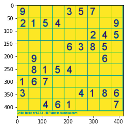

```python
sudoku = io.imread('./sudoku.jpg')
plt.imshow(sudoku)
```

Ensuite, on va traduire la grille sous forme d'un tableau d'images représentant chacune un chiffre.

```python
np.shape(sudoku)
```

```
(435, 420)
```

Connaissant le format du sudoku, propre à ceux de [planete-sudoku](http://www.planete-sudoku.com), on peut le rogner pour obtenir un carré de côté multiple de 9, pour faciliter la division en cases. Ici, je rogne à 414 pixels de côté, 414 étant le plus grand multiple de 9 inférieur à 420.

```python
sudoku = sudoku[:414,:414]
```

```python
image_de_depart = deepcopy(sudoku) # On duplique le sudoku pour comparer à la fin
```

On va isoler chaque case du sudoku, et les ranger dans un tableau. J'introduis une marge pour ne pas garder les pixels des lignes du sudoku. La fonction `découpe` se charge de créer une image 28x28 correspondant à la case aux coordonnées indiquées. Ces images sont en négatif, et calibrées pour s'adapter au format des échantillons sur lesquels on s'entraîne.

```python
c = 46 #414/9 # côté d'une case
def decoupe(im,coordonnées):
    a, b = coordonnées
    marge = 2 # arbitrairement
    case = im[a*c+marge:(a+1)*c-marge,b*c+marge:(b+1)*c-marge]
    case = transform.resize(case, (28,28))
    case[case > .6] = 1
    negatif = 1. - case # Pour respecter le format des images de la méthode de reconnaissance
    return negatif
```

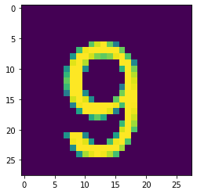

```python
plt.imshow(decoupe(sudoku,(4,1)))
```

```python
np.shape(decoupe(sudoku,(5,7)))
```

```
(28, 28)
```

```python
cases = [[np.reshape(decoupe(sudoku,(i,j)),784) for j in range(9)] for i in range(9)]
```

```python
cases[4][1]
```

[output not shown]

[output cut: 102 more lines]

[output not shown]

On va faire un nouveau tableau, où on rangera les chiffres reconnus.

#### Premier essai (et finalement le dernier à être conservé) de reconnaissance des chiffres

Cette partie est longue à charger (pour moi ça a pris une bonne demi-heure) et ne doit être exécutée qu'une seule fois. C'est la fameuse partie d'apprentissage de l'automate, qui n'est pas encore suffisante pour recopier exactement le sudoku.

```python
from sklearn.datasets import fetch_openml
mnist = fetch_openml(data_id=554) # https://www.openml.org/d/554
```

```python
from sklearn.model_selection import train_test_split
X_train, X_test, y_train, y_test = train_test_split(mnist.data,
                                                    mnist.target.astype('int'), #targets str to int convert
                                                   test_size=1/7.0,
                                                   random_state=0)
```

```python
from sklearn.linear_model import LogisticRegression
clf = LogisticRegression(fit_intercept=True,
                        multi_class='auto',
                        penalty='l1', #lasso regression
                        solver='saga',
                        max_iter=1000,
                        C=50,
                        verbose=2, # output progress
                        n_jobs=5, # parallelize over 5 processes
                        tol=0.01
                         )
clf
```

[output not shown]

```python
clf.fit(X_train, y_train)
```

[output not shown]

```
convergence after 47 epochs took 2287 seconds
```

```
[Parallel(n_jobs=4)]: Done   1 out of   1 | elapsed: 38.1min finished
```

[output not shown]

```python
print(clf.predict(X_test[0:9]))
print(y_test[0:9])
```

```
[0 4 1 2 4 7 7 1 1]
[0 4 1 2 7 9 7 1 1]
```

```python
score = clf.score(X_test, y_test)
score
```

```
0.9195
```

```python
np.shape(X_test[0])
```

```
(784,)
```

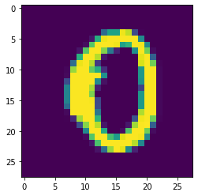

```python
plt.imshow(np.reshape(X_test[0],(28,28)))
```

On fait maintenant un premier test sur une ligne du sudoku.

```python
print(clf.predict(cases[0]))
```

```
[9 5 5 5 3 5 7 5 5]
```

On voit que dans la reconnaissance des chiffres, les cases vides sont identifiées au chiffre 5. On va donc les traiter à part en les remplaçant par zéro avant de traduire les autres chiffres du sudoku.

On représente une case vide par le chiffre 0. On ne traite une case que si un certain nombre de pixels sont sombres. Aussi on cherche un seuil approprié.

```python
np.sum(cases[0][3]) # Ceci est un test pour trouver un seuil adapté
```

```
12.627450980392037
```

```python
def retranscription(sudoku):
    grille = np.zeros((9,9),int)
    for i in range(9):
        for j in range(9):
            im = sudoku[i][j]
            if sum(im)> 20 : # Le seuil à partir duquel on teste les chiffres
                grille[i][j]=clf.predict([sudoku[i][j]])
    return grille
```

```python
grille_trad = retranscription(cases)
print (grille_trad)
```

```
[[9 0 0 0 3 5 7 0 0]
 [2 8 5 4 0 0 0 0 8]
 [0 0 0 0 0 0 2 2 5]
 [0 0 0 0 8 3 8 5 0]
 [0 9 0 0 0 0 0 8 0]
 [0 5 5 5 4 0 0 0 0]
 [5 5 3 0 0 0 0 0 0]
 [3 0 0 0 0 4 8 8 5]
 [0 0 9 5 8 0 0 0 3]]
```

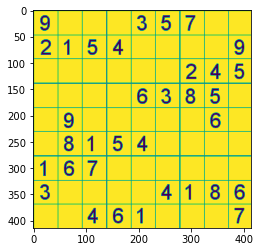

```python
plt.imshow(image_de_depart) # Pour comparer
```

On constate qu'il y a encore beaucoup trop d'erreurs pour espérer recopier proprement et résoudre le sudoku...

J'ai tenté aussi une méthode utilisant Tesseract, mais la reconnaissance nécessitait l'enregistrement des cases en images, et cela m'a semblé trop lourd et laborieux pour l'usage qu'on en faisait. Mon essai suivant était avec OpenCV, mais je ne le laisse pas ici pour ne pas alourdir le code, et parce que ce n'est pas totalement abouti.

### 2 - Résolution du sudoku

Ce bout de code est essentiellement tiré du programme d'un [étudiant de Blaise Pascal](https://info.blaisepascal.fr/projet-sudoku) basé sur le «Back-Tracking». Il s'est aussi intéressé à l'échelle permettant d'évaluer la difficulté d'un sudoku. Là, avec les informations dont on dispose, on peut par exemple situer le niveau du sudoku grâce au nombre de chiffres testés lors de la résolution.

```python
#grille_t = grille_trad.tolist() # A utiliser si on est sûr de l'exactitude de la transcription

# En attendant de perfectionner la reconnaissance des caractères :
grille_av = [[9,0,0,0,3,5,7,0,0],[2,1,5,4,0,0,0,0,9],[0,0,0,0,0,0,2,4,5],[0,0,0,0,6,3,8,5,0],[0,9,0,0,0,0,0,6,0],[0,8,1,5,4,0,0,0,0],[1,6,7,0,0,0,0,0,0],[3,0,0,0,0,4,1,8,6],[0,0,4,6,1,0,0,0,7]]
grille_t = [[9,0,0,0,3,5,7,0,0],[2,1,5,4,0,0,0,0,9],[0,0,0,0,0,0,2,4,5],[0,0,0,0,6,3,8,5,0],[0,9,0,0,0,0,0,6,0],[0,8,1,5,4,0,0,0,0],[1,6,7,0,0,0,0,0,0],[3,0,0,0,0,4,1,8,6],[0,0,4,6,1,0,0,0,7]]

grille_d = [[9,0,0,1,0,0,0,0,5],[0,0,5,0,9,0,2,0,1],[8,0,0,0,4,0,0,0,0],[0,0,0,0,8,0,0,0,0],[0,0,0,7,0,0,0,0,0],[0,0,0,0,2,6,0,0,9],[2,0,0,3,0,0,0,0,6],[0,0,0,2,0,0,9,0,0],[0,0,1,9,0,4,5,7,0]]

iteration = 0 # pour compter le nombre d'appels à la fonction est_valide
test = 0 # pour compter le nombre de chiffres testés lors de la résolution

def affichage(grille): # Fonction qui affiche la grille comme un sudoku réel dans la console
    for l in range(9):
        lig = ""
        for c in range(9) :
            lig += str(grille[l][c])
            if (c+1)%3 ==0:
                lig += " "

        print(lig)
        if 0==(l+1)%3:
            print("------------------")

            #k=chiffre a placer , grille=grille qu'on va changer, l= ligne concernée, c= colonne concernée

def absent_sur_ligne(k, grille, l): # Fonction qui vérifie si le chiffre 'k' est deja présent sur la ligne
    for c in range(9):
        if grille[l][c] == k:
            return False
    return True


def absent_sur_colonne(k, grille, c): # Fonction qui vérifie si le chiffre 'k' est deja présent sur la colonne
    for l in range(9):
        if grille[l][c] == k:
            return False
    return True


def absent_sur_bloc(k , grille , l , c): # Fonction qui vérifie si le chiffre 'k' est deja présent sur le bloc
    _l = l-(l%3)
    _c = c-(c%3)
    for c in range(_c,_c+3):
        for l in range(_l,_l+3):
            if grille[l][c] == k:
                return False
    return True


def est_valide(grille , position): # Fonction qui vérifie si on doit modifier la case, la case est définie avec le paramètre position qui s'agrémente de 1 à chaque fois
    global test
    global iteration
    iteration = iteration+1
    if position == 9*9:
        return True

    l = position//9
    c = position%9

    if grille[l][c] != 0:
        return est_valide(grille , position+1)
    else:
        for k in range(1,10):
            test = test+1
            if absent_sur_ligne(k,grille,l) \
            and absent_sur_colonne(k,grille,c) \
            and absent_sur_bloc(k,grille,l,c):
                grille[l][c] = k
                if est_valide(grille,position+1):
                    return True

    grille[l][c] = 0
    return False


print("Grille avant\n") # C'est la partie du programme qui appelle les fonctions affichage et est_valide
affichage(grille_t)
est_valide(grille_t,0)

print("Grille apres\n")
affichage(grille_t)
print("\nNombre d'appels à la fonction est_valide : ")
print(iteration)
print("\nNombre de chiffres testés lors de la résolution : ")
print(test)
```

```
Grille avant

900 035 700
215 400 009
000 000 245
------------------
000 063 850
090 000 060
081 540 000
------------------
167 000 000
300 004 186
004 610 007
------------------
Grille apres

946 235 718
215 487 639
738 196 245
------------------
472 963 851
593 871 462
681 542 973
------------------
167 328 594
329 754 186
854 619 327
------------------

Nombre d'appels à la fonction est_valide :
208

Nombre de chiffres testés lors de la résolution :
1095
```

Pour une grille difficile, le nombre de chiffres testés est plutôt de l'ordre du million voire de la dizaine de millions, de même que le nombre d'appels à la fonction principale, `est_valide`. (Essayer d'appeler la fonction avec grille_d pour un exemple de grille difficile)

### 3 - Remplissage de la grille avec les chiffres en écriture manuscrite

On récupère chaque chiffre en écriture manuscrite à partir de l'image fournie.

[figure not shown]

```python
img = io.imread( "./digits.jpg", as_gray=True)
```

```python
img.shape, img.min(), img.max()
```

```
((85, 366), 0.03529411764705882, 0.9495850980392156)
```

```python
img[img > .6] = 1
```

```python
xx = img.sum(axis = 0)
xx[ xx < 85] = 0
yy = img.sum(axis = 1)
yy[ yy < 366] = 0
```

```python
y,x = img.shape

cx = np.convolve(xx, np.array([1,1,1]), mode = 'same' )
index = np.where(cx == 2*y)[0][1:-1]
strips = index.reshape((-1,2))
strips
```

```
array([[ 42,  57],
       [ 85,  90],
       [108, 129],
       [143, 161],
       [177, 200],
       [210, 235],
       [239, 256],
       [271, 292],
       [303, 327],
       [335, 354]], dtype=int64)
```

```python
cleaned = []
for strip in strips:
    a,b = strip
    im = img[:,a:b]
    y,x = im.shape
    index = np.where( im.sum(axis=1) < x )[0]
    bottom, top = index.max(), index.min()
    cleaned.append(img[top:bottom,a:b])
```

```python
import pickle
with open("digits.pkl", "wb") as fp:
    pickle.dump(cleaned, fp)
```

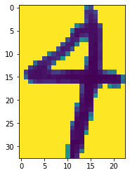

```python
plt.imshow(cleaned[4])
```

Avec chacun des chiffres en écriture manuscrite, on va créer une vignette carrée que l'on n'aura plus qu'à coller à la bonne place sur l'image.

```python
def redim(im,c): # crée une vignette carrée (à la taille des cases de la grille) du chiffre avec l'écriture manuscrite
    n, p = len(im), len(im[0])
    ratio = p/n
    case = np.zeros(shape=(c,c))+1.
    if n>=p :
        p_prime = int(c*ratio)
        vignette = transform.resize(im, (c,p_prime))
        marge = int((c-p_prime)/2)
        case[:,marge:marge+p_prime] = vignette
    else :
        n_prime = int(c/ratio)
        vignette = transform.resize(im, (n_prime,c))
        marge = int((c-n_prime)/2)
        case[marge:marge+n_prime,:] = vignette
    return case
```

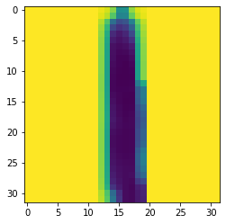

```python
case_red = int(16/23*c)
chiffres = [redim(cleaned[i],case_red) for i in range(10)]
plt.imshow(chiffres[1])
```

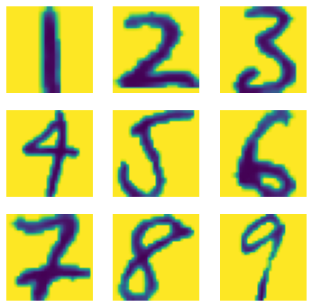

```python
fig, axs = plt.subplots(3, 3)
fig.set_size_inches(6,6)
axs = axs.ravel()

for ax in axs:
    ax.set_axis_off()

for k, ax in zip(range(1,10),axs):
    ax.imshow(chiffres[k]) ;
```

Ainsi tous les chiffres peuvent être traités de la même manière.

```python
np.shape(chiffres[3])
```

```
(32, 32)
```

On implémente une fonction ecrit_chiffre qui remplace les pixels correspondant dans l'image de départ (ici appelée s) pour inscrire le chiffre donné en argument aux coordonnées indiquées.

```python
def ecrit_chiffre(s,chiffre,coordonnées):
    a,b = coordonnées
    décalage = int((c - case_red)/2)
    x = int(a*c + décalage)
    y = int(b*c + décalage)
    s[x:x+case_red, y:y+case_red] = 255*chiffres[chiffre]
```

```python
#ecrit_chiffre(sudoku,2,(1,7))
#plt.imshow(sudoku)
```

```python
def remplissage(image,solution):
    for i in range(9):
        for j in range(9):
            k = solution[i][j]
            if k!=0 and k!=grille_av[i][j]:
                ecrit_chiffre(image,k,(i,j))
    return image
```

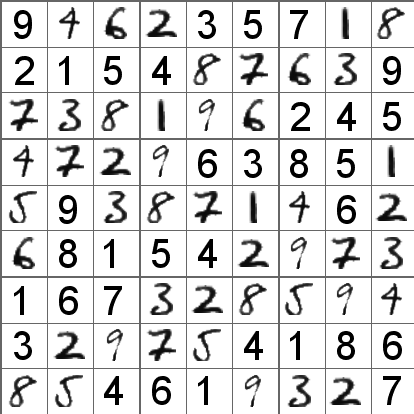

```python
im = Image.fromarray(remplissage(sudoku,grille_t))
im
```

```python
im.save("Solution.jpg")
```

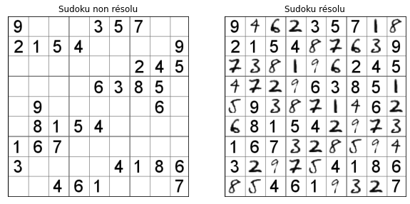

```python
fig, axs = plt.subplots(1, 2)
fig.set_size_inches(10,10)
plt.subplot(121),plt.imshow(image_de_depart,cmap = 'gray')
plt.title('Sudoku non résolu'), plt.xticks([]), plt.yticks([])
plt.subplot(122),plt.imshow(im,cmap = 'gray')
plt.title('Sudoku résolu'), plt.xticks([]), plt.yticks([])

plt.show()
```